# Olympic Advertisements

Rosie Armstrong

# **Olympic Advertisements**

## Overview

This data aims to explore the question, ‘Does the type of object being advertised have an influence on how many males versus females are included as main actors in the advertisement?’ The data about advertisements during the 2018 Winter Olympics was collected while watching a live broadcast on the NBC channel on the 9, 10, and 15 of February. I was interested in collecting this data to see if there was a difference in gender representation for products that are typically advertised as masculine (cars, certain foods) versus products that are typically advertised as feminine (household and cleaning items). While acknowledging the stereotypes present in media as far as gender representations and stereotypes, I was hoping that I would not find a difference in representation of masculine versus feminine characters in the advertisements; products such as cars, cleaning products, and food are not specific in function to one gender.

## Data dictionary

Here is a data dictionary for the ‘Olympic Advertisements’ dataset:

- **prod_name**: A character variable with the full name of the product or company being advertised in the commercial. Brand name if medication.
- **prod_type**: A character variable with the type of product being advertised. Possibile categories include: Household, Medication/Medical, Lifestyle, Food, Movie/TV, Car, Other.
- **male**: A numerical variable with the number of men or males present as main ‘characters’ in the focus of the commercial. This number does not include background characters.
- **female**: A numerical variable with the number of women or females present as main ‘characters’ in the focus of the commercial. This number does not include background characters.
- **music**: A categorical variable for if music is included in the commercial. Coded as ‘Y’ for yes, and if no music is included in the commercial, coded as ‘N’ for no.
- **color**: A categorical variable for if the commercial is shown in color. Coded as ‘Y’ for yes, and if the commercial is shown in black and white, coded as ‘N’ for no.
- **narration**: A categorical vairable for if the commercial is narrated. Coded as ‘Y’ for yes, if the commercial does not have narration over the whole commercial, coded as ‘N’ for no. This does not include brief audio at the end of the commercial.

Which can be read in as follows:

```r
ads <- read_csv("https://raw.githubusercontent.com/URstats/stat209-s18-rosiea26/master/ads.csv")
ads
```

## Exploratory Analysis

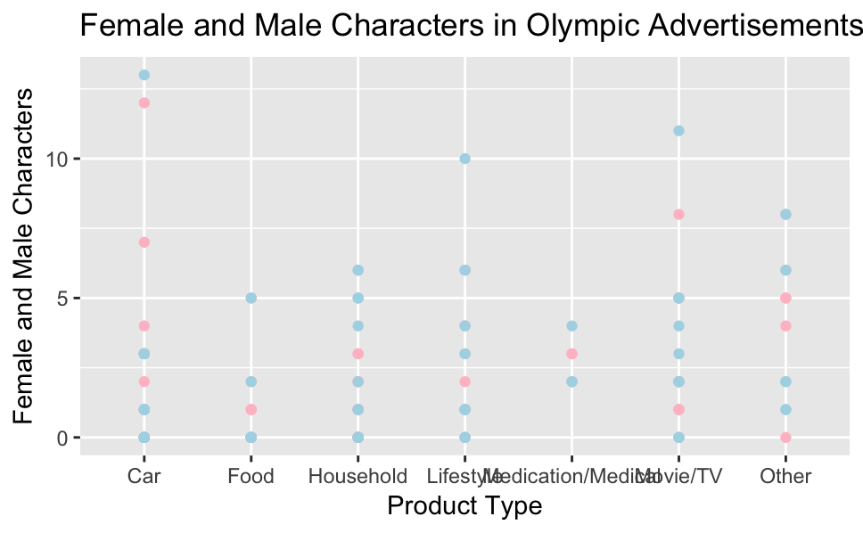

This graph displays all of the male and female characters in each type of advertisement during the 2018 Olympics. The light pink dots are male characters, and the light blue dots are female characters. There is a relatively even amount of male versus female characters, with slightly more advertisements with female characters overall. Not all of the advertisements are represented here as single data points, because some advertisements include the same amounts of male and female characters as other advertisements.

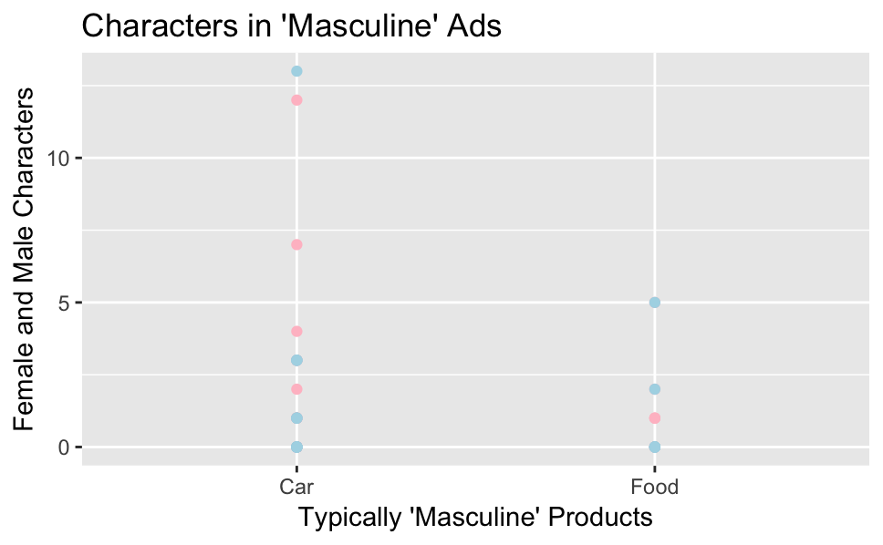

Again, not all of the 27 objects are displayed here because some advertisements contain the exact same numbers of male or female characters as others, so the data points lie on top of one another. However, even so, the typically ‘masculine’ products (such as ‘Ford Expedition’, ‘Longhorn Steakhouse’ and other cars and foods) are not dominated by male (pink) representation in the commercial: females (blue) are also present to a similar degree.

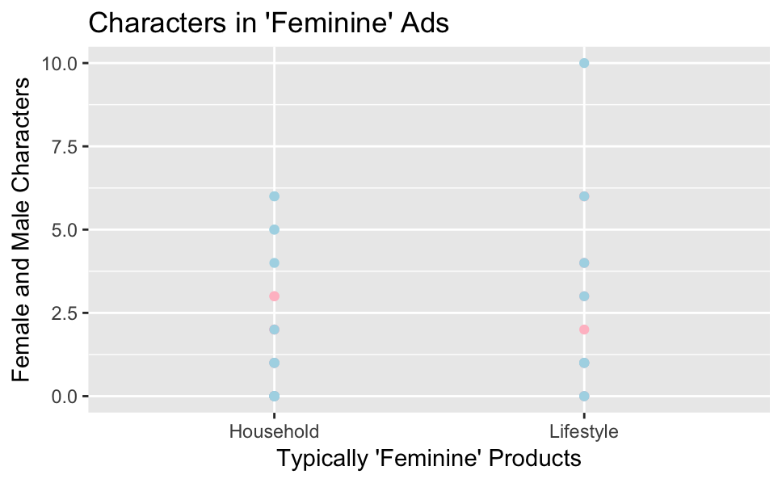

This graph displays typically ‘feminine’ products (such as Green Front Furniture store, Swarovski diamonds, and Aveeno lotion). There are many more data points displaying female characters (blue) than male characters (pink) as opposed to the relatively even distribution in the previous graph for ‘masculine’ products.

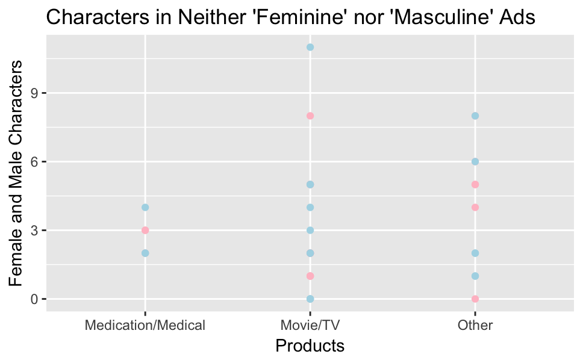

In products that are non-gendered (such as medication, movies and TV shows or channels, and ‘other’ products such as credit unions and law firms), there is a relatively even distribution of female (blue) and male (pink) characters.

## Conclusion

From this data, we can conclude that there is little to no difference in the distribution of genders exhibited across advertisements for typically masculine and neutral products. However, the exception is for products that are typically seen as feminine; these products, including household and lifestyle products, include many more female than male characters in the advertisements. This pattern may be coincidental, but it may also have to do with the deeper issue of gender stereotypes and biases against females. Though there stands a large issue in the advertisement and entertainment industry to be solved about gender stereotypes, there has been much improvement over the past few decades. It would be interesting to conduct research in the future including print and other types of advertisements, and to compare current advertisements to advertisements from the past few decades.